# Practice Set p.1

GitHub link: https://github.com/TylerWolfWilliams/GSB-544

```python
import pandas as pd
import numpy as np
import matplotlib.pyplot as plt
from sklearn.model_selection import train_test_split
from sklearn.preprocessing import StandardScaler
from sklearn.pipeline import Pipeline
from sklearn.neighbors import KNeighborsClassifier
from sklearn.tree import DecisionTreeClassifier, plot_tree
from sklearn.discriminant_analysis import LinearDiscriminantAnalysis
from sklearn.linear_model import LogisticRegression
from sklearn.metrics import accuracy_score, f1_score, roc_auc_score
```

Our dataset consists of clinical data from patients who entered the hospital complaining of chest pain (“angina”) during exercise. The information collected includes:

- `age` : Age of the patient
- `sex` : Sex of the patient
- `cp` : Chest Pain type
  - Value 0: asymptomatic
  - Value 1: typical angina
  - Value 2: atypical angina
  - Value 3: non-anginal pain
- `trtbps` : resting blood pressure (in mm Hg)
- `chol` : cholesterol in mg/dl fetched via BMI sensor
- `restecg` : resting electrocardiographic results
  - Value 0: normal
  - Value 1: having ST-T wave abnormality (T wave inversions and/or ST elevation or depression of > 0.05 mV)
  - Value 2: showing probable or definite left ventricular hypertrophy by Estes’ criteria
- `thalach` : maximum heart rate achieved during exercise
- `output` : the doctor’s diagnosis of whether the patient is at risk for a heart attack
  - 0 = not at risk of heart attack
  - 1 = at risk of heart attack

## library imports here

ha = pd.read_csv(“https://www.dropbox.com/s/aohbr6yb9ifmc8w/heart_attack.csv?dl=1”)

## Q1: Natural Multiclass Models

Fit a multiclass KNN, Decision Tree, and LDA for the heart disease data; this time predicting the type of chest pain (categories 0 - 3) that a patient experiences. For the decision tree, plot the fitted tree, and interpret the first couple splits.

```python
ha = pd.read_csv("https://www.dropbox.com/s/aohbr6yb9ifmc8w/heart_attack.csv?dl=1")

feature_cols = ['age', 'sex', 'trtbps', 'chol', 'restecg', 'thalach', 'output']
X = ha[feature_cols].copy()
y = ha['cp'].copy()

X_train, X_test, y_train_cp, y_test_cp = train_test_split(
    X, y, test_size=0.30, random_state=42, stratify=y
)
```

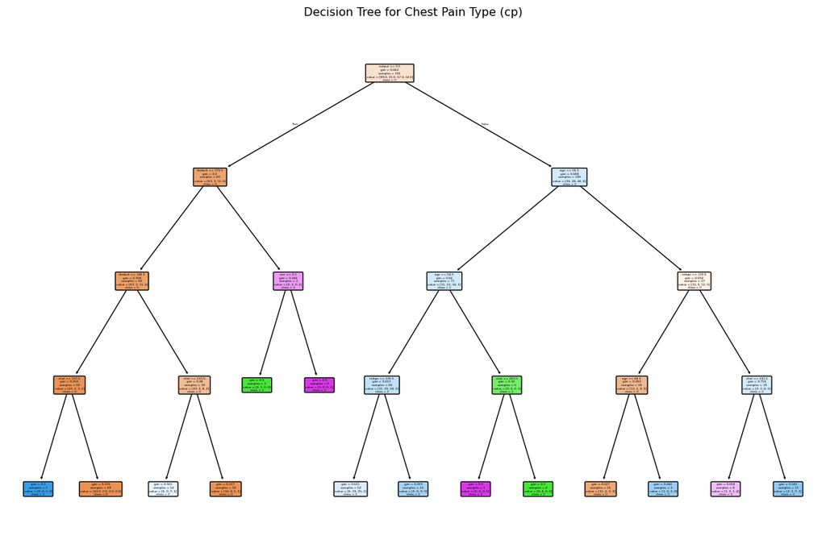

```
Q1 — Multiclass Model Accuracies
                      Model  Test Accuracy
                        LDA       0.536585
Decision Tree (max_depth=4)       0.500000
                  KNN (k=7)       0.475610

First Two Splits in the Decision Tree:
Root Split: output <= 0.500
Next Split: thalach <= 173.500
```

```python
knn_pipe = Pipeline([
    ("scaler", StandardScaler()),
    ("clf", KNeighborsClassifier(n_neighbors=7))
])
lda_pipe = Pipeline([
    ("scaler", StandardScaler()),
    ("clf", LinearDiscriminantAnalysis())
])
dt_pipe = Pipeline([  # pipeline for consistency; scaler not needed
    ("clf", DecisionTreeClassifier(random_state=42, max_depth=4))
])

knn_pipe.fit(X_train, y_train_cp)
lda_pipe.fit(X_train, y_train_cp)
dt_pipe.fit(X_train, y_train_cp)

acc_knn = accuracy_score(y_test_cp, knn_pipe.predict(X_test))
acc_lda = accuracy_score(y_test_cp, lda_pipe.predict(X_test))
acc_dt  = accuracy_score(y_test_cp, dt_pipe.predict(X_test))

acc_df = pd.DataFrame({
    "Model": ["KNN (k=7)", "LDA", "Decision Tree (max_depth=4)"],
    "Test Accuracy": [acc_knn, acc_lda, acc_dt]
}).sort_values("Test Accuracy", ascending=False, ignore_index=True)

# Decision tree plot
plt.figure(figsize=(12, 8))
plot_tree(
    dt_pipe.named_steps["clf"],
    feature_names=feature_cols,
    class_names=[str(c) for c in sorted(y.unique())],
    filled=True,
    rounded=True
)
plt.title("Decision Tree for Chest Pain Type (cp)")
plt.tight_layout()
plt.show()

# First couple splits (stored as strings; no print)
_tree = dt_pipe.named_steps["clf"].tree_
_feat_idx = _tree.feature
_thresh = _tree.threshold

def _node_desc(node_id):
    f = _feat_idx[node_id]
    return f"{feature_cols[f]} <= {_thresh[node_id]:.3f}" if f >= 0 else "leaf"

root_split = _node_desc(0)
_left = _tree.children_left[0]
_right = _tree.children_right[0]
next_node = _left if _feat_idx[_left] >= 0 else _right
next_split = _node_desc(next_node)

print("\nQ1 — Multiclass Model Accuracies")
print(acc_df.to_string(index=False))

print("\nFirst Two Splits in the Decision Tree:")
print(f"Root Split: {root_split}")
print(f"Next Split: {next_split}")
```

## Q2: OvR

Create a new column in the `ha` dataset called `cp_is_3`, which is equal to `1` if the `cp` variable is equal to `3` and `0` otherwise.

Then, fit a Logistic Regression to predict this new target, and report the **F1 Score**.

Repeat for the other three `cp` categories. Which category was the OvR approach best at distinguishing?

```python
ha["cp_is_3"] = (ha["cp"] == 3).astype(int)

ovr_rows = []
for cls in sorted(y.unique()):
    y_train_bin = (y_train_cp == cls).astype(int)
    y_test_bin  = (y_test_cp == cls).astype(int)
    ovr_pipe = Pipeline([
        ("scaler", StandardScaler()),
        ("clf", LogisticRegression(max_iter=1000))
    ])
    ovr_pipe.fit(X_train, y_train_bin)
    y_pred = ovr_pipe.predict(X_test)
    f1 = f1_score(y_test_bin, y_pred, zero_division=0)
    ovr_rows.append({"cp category": cls, "F1 (OvR LR)": f1})

ovr_df = pd.DataFrame(ovr_rows).sort_values("F1 (OvR LR)", ascending=False, ignore_index=True)
ovr_best_category = ovr_df.iloc[0]["cp category"]

print("\nQ2 — One-vs-Rest Logistic Regression (OvR)")
print(ovr_df.to_string(index=False))
print(f"\nBest Distinguished Category (Highest F1): {ovr_best_category}")
```

```
Q2 — One-vs-Rest Logistic Regression (OvR)
 cp category  F1 (OvR LR)
           0     0.731707
           2     0.148148
           1     0.125000
           3     0.000000

Best Distinguished Category (Highest F1): 0.0
```

## Q3: OvO

Reduce your dataset to only the `0` and `1` types of chest pain.

Then, fit a Logistic Regression to predict between the two groups, and report the **ROC-AUC**.

Repeat comparing category `0` to `2` and `3`. Which pair was the OvO approach best at distinguishing? y_cp

```python
pairs = [(0,1), (0,2), (0,3)]
ovo_rows = []

for a, b in pairs:
    mask = y.isin([a, b])
    X_ab = X.loc[mask]
    y_ab = y.loc[mask]
    y_bin = (y_ab == b).astype(int)  # label class b as 1

    X_tr, X_te, y_tr, y_te = train_test_split(
        X_ab, y_bin, test_size=0.30, random_state=42, stratify=y_bin
    )
    ovo_pipe = Pipeline([
        ("scaler", StandardScaler()),
        ("clf", LogisticRegression(max_iter=1000))
    ])
    ovo_pipe.fit(X_tr, y_tr)
    proba = ovo_pipe.predict_proba(X_te)[:, 1]
    auc = roc_auc_score(y_te, proba)
    ovo_rows.append({"Pair": f"{a} vs {b}", "ROC-AUC (OvO LR)": auc})

ovo_df = pd.DataFrame(ovo_rows).sort_values("ROC-AUC (OvO LR)", ascending=False, ignore_index=True)
ovo_best_pair = ovo_df.iloc[0]["Pair"]

print("\nQ3 — One-vs-One Logistic Regression (OvO)")
print(ovo_df.to_string(index=False))
print(f"\nBest Distinguished Pair (Highest ROC-AUC): {ovo_best_pair}")
```

```
Q3 — One-vs-One Logistic Regression (OvO)
  Pair  ROC-AUC (OvO LR)
0 vs 2          0.881410
0 vs 3          0.730769
0 vs 1          0.727811

Best Distinguished Pair (Highest ROC-AUC): 0 vs 2
```